# Filling in temperature data gaps

# Regression Analysis for Water Temperature Data

The goal of this analysis is to fill in data gaps where temperature data are missing or the time series is incomplete in order to make the dataset more useful for SR JPE modeling. Temperature is an important covariate in understanding juvenile production though the completeness of these data vary by location.

Currently this analysis relies on a regression model and is performed for the Feather River and Yuba River. The resulting dataset with predicted values is saved and integrated in the development of a water temperature dataset.

## Data used to build models: Butte Creek

Butte Creek is used to build the regression models because the time series is complete and the data are high quality.

- Date range covered in the Butte Creek temperature data is 1999 - 2024

## Overall approach for water temperature regression:

1. Prepare datasets for regression analysis (dataset with no missing data is used to train the model and dataset with missing data is used to predict)
2. Fit linear regression models for mean, min, and max temperatures
3. Make predictions for missing data using the fitted models
4. Combine predictions with actual measurements
5. Visualize the predicted and actual temperature over time to asses model performance trends

## Feather River

### Data Preparation and Approach

1. Pull in gage data from CDEC (GRL will represent the High Flow Channel (HFC) and FRA will represent the Low Flow Channel (LFC):
- GRL (2003-03-05 to 2007-06-01 H; 2020-01-04 to present): located after Thermalito Afterbay
- FRA (2002-01-01 to present): located between Lake Oroville and Thermalito Afterbay
2. Prepare datasets for regression analysis:
- Dataset with no missing data to train and test the model (Butte Creek and Feather River)
- Dataset with missing data to make predictions (Feather River)
3. Use data where there are no missing data from either dataset for regression modeling
4. Use the regression model to make predictions from the testing dataset and evaluate
5. Use the model to make predictions for missing data

### Low Flow Channel (LFC)

#### Visually check the relationship between Butte Creek and Feather River LFC water temperature

There is a linear correlation between mean water temperature on Butte Creek and Feather River LFC. The plots bellow suggest a strong linear relationship between the mean, max and min water temperatures of Butte Creek and Feather River LFC. The positive slope of the linear trend line implies that higher water temperatures in Butte Creek are associated with higher water temperatures in Feather River LFC. These visual representations support the results of the linear regression analysis, which identified a statistically significant relationship between the mean, max and min water temperatures of these two locations.

*Plot of mean temp for Feather River LFC and Butte Creek*

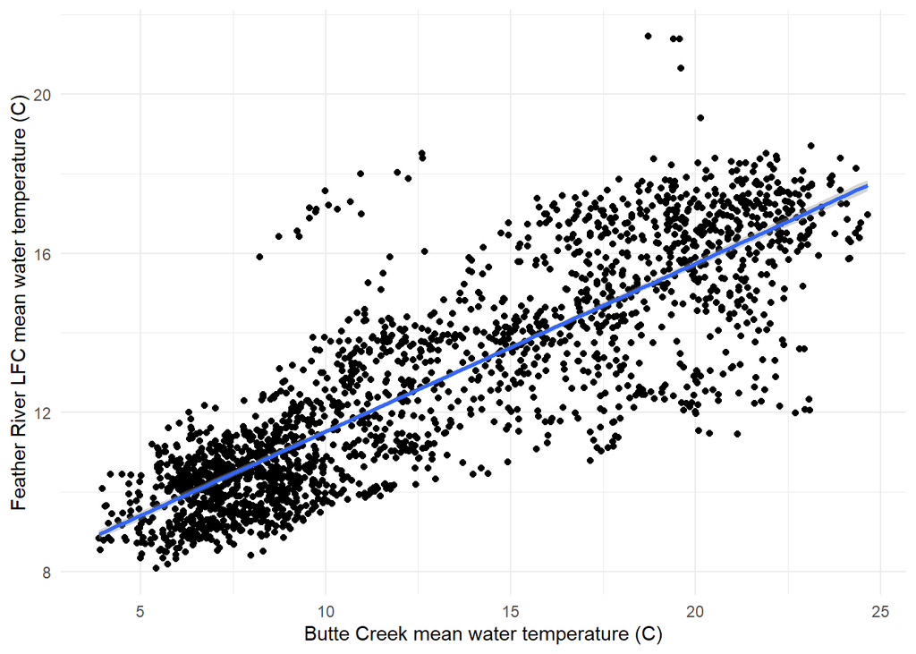

*Plot of min temp for Feather River LFC and Butte Creek*

Similar to mean temperature, there is a linear correlation for min temperature.

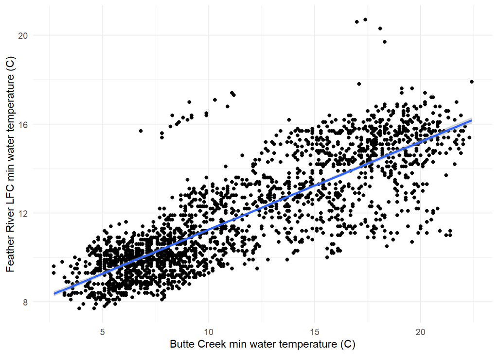

*Plot of max temp for Feather River LFC and Butte Creek*

Similar to mean and min, there is a linear correlation for max temperature.

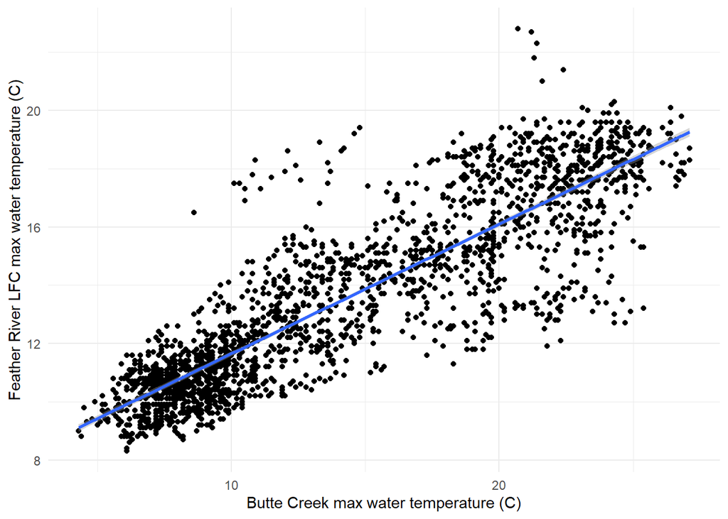

#### Building Mean Regression

- Splitting data
- Building the model
- Model summary
- Making predictions
- Evaluating predictions

```
##
## Call:
## lm(formula = temp ~ date + butte_temp, data = train)
##
## Residuals:
##     Min      1Q  Median      3Q     Max
## -4.8812 -0.8435  0.0328  0.8086  5.9177
##
## Coefficients:
##               Estimate Std. Error t value Pr(>|t|)
## (Intercept) -6.154e+00  1.022e+00   -6.02 2.13e-09 ***
## date         7.169e-04  5.423e-05   13.22  < 2e-16 ***
## butte_temp   4.151e-01  6.026e-03   68.88  < 2e-16 ***
## ---
## Signif. codes:  0 '***' 0.001 '**' 0.01 '*' 0.05 '.' 0.1 ' ' 1
##
## Residual standard error: 1.379 on 1701 degrees of freedom
##   (1 observation deleted due to missingness)
## Multiple R-squared:  0.7487, Adjusted R-squared:  0.7484
## F-statistic:  2533 on 2 and 1701 DF,  p-value: < 2.2e-16
```

```
## [1] 0.07992199
```

#### Building Min Regression

- Splitting data
- Building the Model
- Model Summary
- Making predictions
- Evaluating predictions

```
##
## Call:
## lm(formula = temp ~ date + butte_temp, data = train)
##
## Residuals:
##     Min      1Q  Median      3Q     Max
## -4.6808 -0.7931  0.0219  0.7601  6.1661
##
## Coefficients:
##               Estimate Std. Error t value Pr(>|t|)
## (Intercept) -3.682e+00  9.541e-01  -3.859 0.000118 ***
## date         5.806e-04  5.062e-05  11.470  < 2e-16 ***
## butte_temp   3.970e-01  6.200e-03  64.025  < 2e-16 ***
## ---
## Signif. codes:  0 '***' 0.001 '**' 0.01 '*' 0.05 '.' 0.1 ' ' 1
##
## Residual standard error: 1.288 on 1701 degrees of freedom
##   (1 observation deleted due to missingness)
## Multiple R-squared:  0.7186, Adjusted R-squared:  0.7183
## F-statistic:  2172 on 2 and 1701 DF,  p-value: < 2.2e-16
```

```
## [1] 0.09077666
```

#### Building Max Regression

- Splitting data
- Building the Model
- Model Summary
- Making predictions
- Evaluating predictions

```
##
## Call:
## lm(formula = temp ~ date + butte_temp, data = train)
##
## Residuals:
##     Min      1Q  Median      3Q     Max
## -5.2646 -0.7913  0.0096  0.8165  5.8357
##
## Coefficients:
##               Estimate Std. Error t value Pr(>|t|)
## (Intercept) -7.893e+00  1.050e+00  -7.519 8.89e-14 ***
## date         8.047e-04  5.562e-05  14.467  < 2e-16 ***
## butte_temp   4.397e-01  5.656e-03  77.737  < 2e-16 ***
## ---
## Signif. codes:  0 '***' 0.001 '**' 0.01 '*' 0.05 '.' 0.1 ' ' 1
##
## Residual standard error: 1.429 on 1701 degrees of freedom
##   (1 observation deleted due to missingness)
## Multiple R-squared:  0.7894, Adjusted R-squared:  0.7891
## F-statistic:  3187 on 2 and 1701 DF,  p-value: < 2.2e-16
```

```
## [1] 0.08252082
```

#### Predictions

- Combine Predictions (mean, min, max data frames into one)
- Reshape data

The plot shows the predicted mean temperature of the Feather River LFC over time. The line represents the trend of the predicted mean temperatures, indicating how they change as the date progresses. This visualization helps to identify any patterns or trends in the mean water temperature over the observed period.

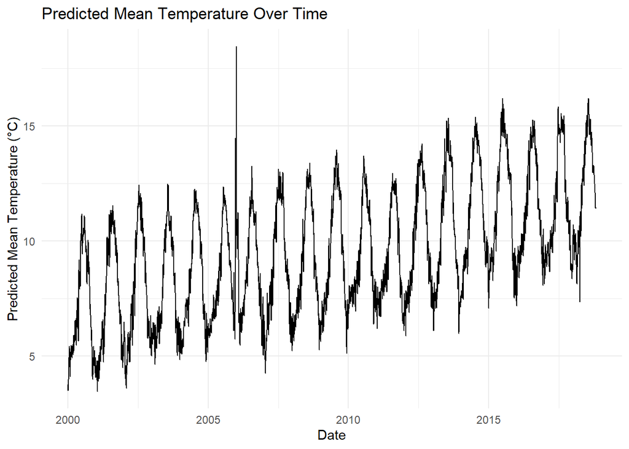

The plot illustrates the predicted minimum temperature of the Feather River LFC over time. The line represents the trend of the predicted minimum temperatures, showing how they vary across different dates. This helps to understand the behavior of the minimum water temperatures in the river.

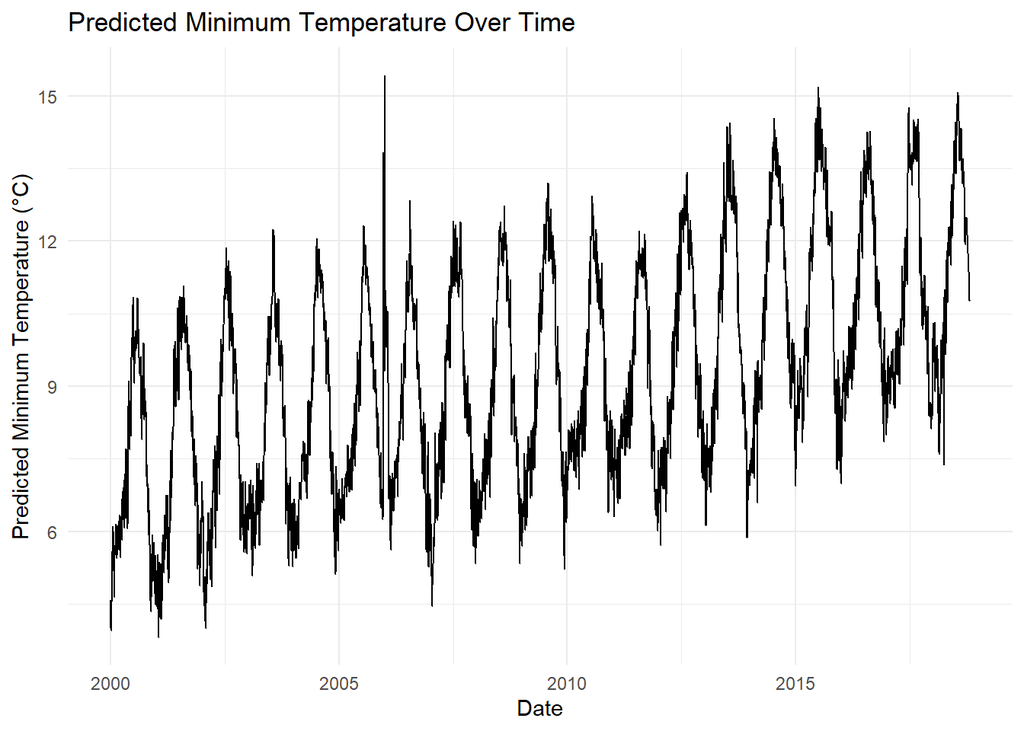

The plot shows the predicted maximum temperature of the Feather River LFC over time. The line indicates the trend of the predicted maximum temperatures, showing how they change with respect to the date. This plot helps to visualize the highest expected water temperatures in the river over the given period.

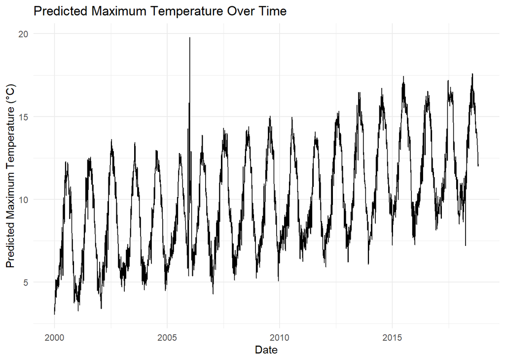

#### Full dataset

- Join with original data (merge combined predictions with the original dataset that includes gage agency and gage number)
- Visualize combined data

The plot shows how the mean, minimum, and maximum temperatures of the Upper Feather River LFC vary over time. Interpolated values are seamlessly integrated where observed data is missing, ensuring a continuous temperature trend. The different colors for each statistic (mean, min, max) help in distinguishing the temperature trends and understanding the temperature fluctuations.

```
## Rows: 26,877
## Columns: 7
## Groups: stream, date, statistic, gage_agency, gage_number, site_group [26,877]
## $ date        <date> 1999-12-31, 1999-12-31, 1999-12-31, 2000-01-01, 2000-01-0…
## $ stream      <chr> "feather river", "feather river", "feather river", "feathe…
## $ site_group  <chr> "upper feather lfc", "upper feather lfc", "upper feather l…
## $ gage_agency <chr> "interpolated", "interpolated", "interpolated", "interpola…
## $ gage_number <chr> "interpolated", "interpolated", "interpolated", "interpola…
## $ statistic   <chr> "mean", "max", "min", "mean", "max", "min", "mean", "max",…
## $ value       <dbl> 3.692121, 3.033571, 4.584134, 3.762018, 3.474071, 4.386230…
```

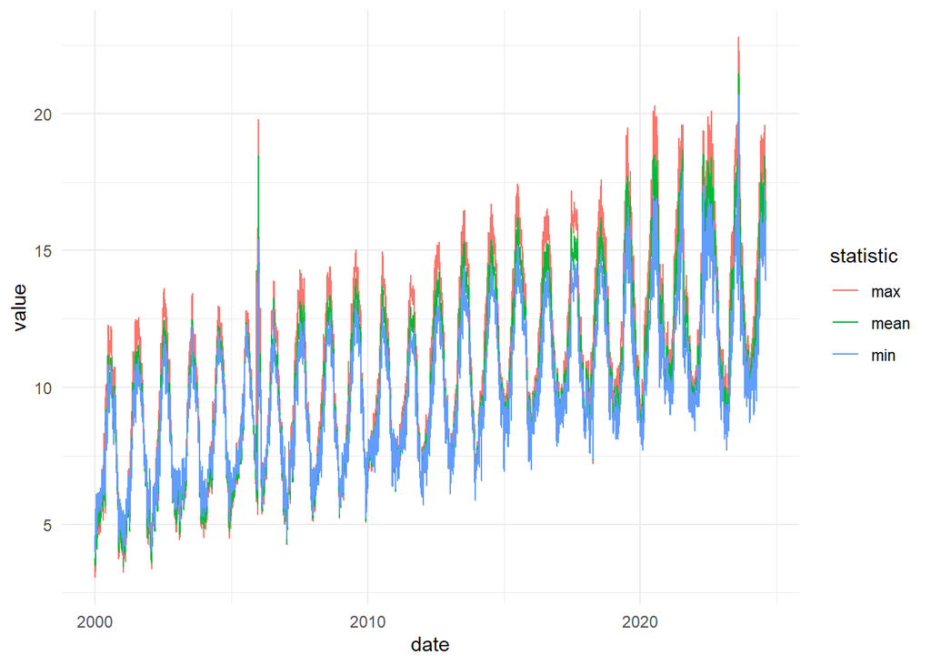

### HFC

#### Visually check the relationship between Butte Creek and Feather River HFC water temperature

There is a linear correlation between mean water temperature on Butte Creek and Feather River HFC. The plots bellow suggest a strong linear relationship between the mean, max and min water temperatures of Butte Creek and Feather River HFC. The positive slope of the linear trend line implies that higher water temperatures in Butte Creek are associated with higher water temperatures in Feather River HFC. These visual representations support the results of the linear regression analysis, which identified a statistically significant relationship between the mean, max and min water temperatures of these two locations.

*Plot of mean temp for Feather River HFC and Butte Creek*

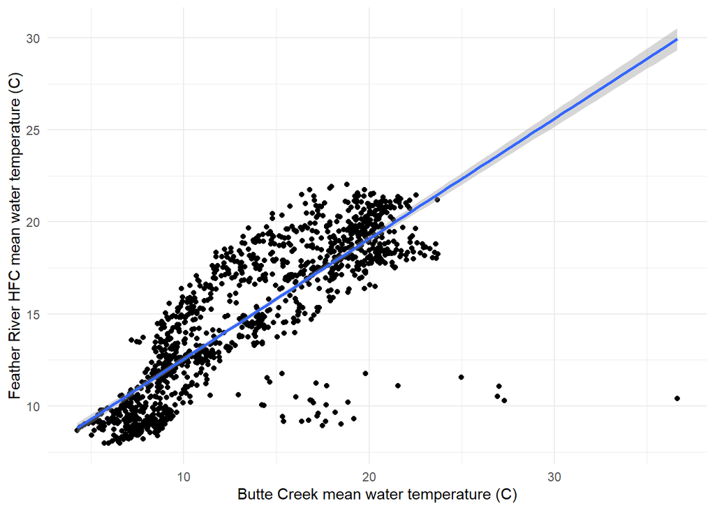

*Plot of min temp for Feather River HFC and Butte Creek*

Similar to mean temperature, there is a linear correlation for min temperature.

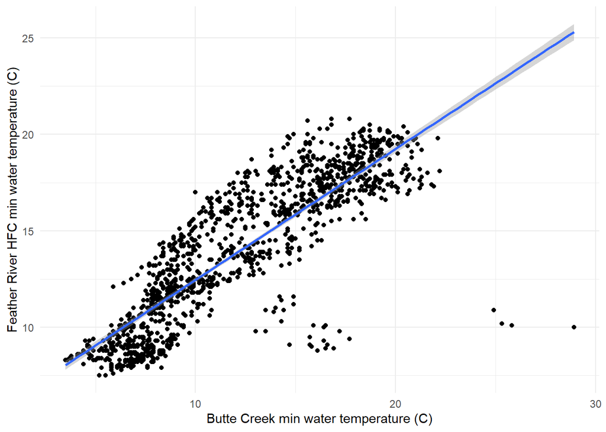

*Plot of max temp for Feather River HFC and Butte Creek*

Similar to mean and min, there is a linear correlation for max temperature.

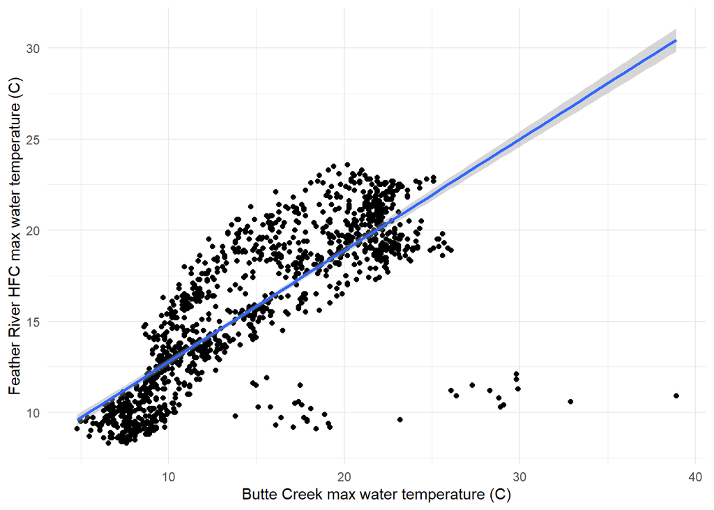

#### Building Mean Regression

- Splitting data
- Building the Model
- Model Summary
- Making predictions
- Evaluating predictions

```r
# HFC regression and predictions

# MEAN Regression
split <-rsample::initial_split(feather_hfc_regression_data_mean, prop = 0.8)
train <- rsample::training(split)
test <- rsample::testing(split)
feather_hfc_mod_mean <- lm(temp ~ date + butte_temp, data = train)
summary(feather_hfc_mod_mean)
```

```
##
## Call:
## lm(formula = temp ~ date + butte_temp, data = train)
##
## Residuals:
##      Min       1Q   Median       3Q      Max
## -19.2834  -1.3106  -0.1356   1.4368   4.9534
##
## Coefficients:
##               Estimate Std. Error t value Pr(>|t|)
## (Intercept) 14.4760477  2.4424839   5.927 4.25e-09 ***
## date        -0.0006617  0.0001917  -3.451 0.000582 ***
## butte_temp   0.6526007  0.0139813  46.677  < 2e-16 ***
## ---
## Signif. codes:  0 '***' 0.001 '**' 0.01 '*' 0.05 '.' 0.1 ' ' 1
##
## Residual standard error: 2.245 on 1000 degrees of freedom
##   (1 observation deleted due to missingness)
## Multiple R-squared:  0.6855, Adjusted R-squared:  0.6848
## F-statistic:  1090 on 2 and 1000 DF,  p-value: < 2.2e-16
```

```r
test_predict <- predict(feather_hfc_mod_mean, test)
test_predict_df <- test |>
  mutate(predicted = test_predict)
# evaluate predictions - MAPE of 10% is not bad
mean(abs((
  test_predict_df$predicted - test_predict_df$temp
)) / test_predict_df$temp)
```

```
## [1] 0.124859
```

#### Building Min Regression

- Splitting data
- Building the Model
- Model Summary
- Making predictions
- Evaluating predictions

```
##
## Call:
## lm(formula = temp ~ date + butte_temp, data = train)
##
## Residuals:
##      Min       1Q   Median       3Q      Max
## -14.9225  -1.1583  -0.0014   1.2942   4.3609
##
## Coefficients:
##               Estimate Std. Error t value Pr(>|t|)
## (Intercept) 15.6454583  2.1972302   7.121 2.05e-12 ***
## date        -0.0007770  0.0001727  -4.499 7.61e-06 ***
## butte_temp   0.6744995  0.0138095  48.843  < 2e-16 ***
## ---
## Signif. codes:  0 '***' 0.001 '**' 0.01 '*' 0.05 '.' 0.1 ' ' 1
##
## Residual standard error: 2.016 on 1000 degrees of freedom
##   (1 observation deleted due to missingness)
## Multiple R-squared:  0.7048, Adjusted R-squared:  0.7042
## F-statistic:  1194 on 2 and 1000 DF,  p-value: < 2.2e-16
```

```
## [1] 0.1068269
```

#### Building Max Regression

- Splitting data
- Building the Model
- Model Summary
- Making predictions
- Evaluating predictions

```
##
## Call:
## lm(formula = temp ~ date + butte_temp, data = train)
##
## Residuals:
##      Min       1Q   Median       3Q      Max
## -14.2424  -1.3401  -0.2102   1.5113   5.7510
##
## Coefficients:
##               Estimate Std. Error t value Pr(>|t|)
## (Intercept) 15.7712715  2.7008875   5.839 7.08e-09 ***
## date        -0.0007478  0.0002119  -3.528 0.000437 ***
## butte_temp   0.6427556  0.0138636  46.363  < 2e-16 ***
## ---
## Signif. codes:  0 '***' 0.001 '**' 0.01 '*' 0.05 '.' 0.1 ' ' 1
##
## Residual standard error: 2.468 on 1000 degrees of freedom
##   (1 observation deleted due to missingness)
## Multiple R-squared:  0.6826, Adjusted R-squared:  0.682
## F-statistic:  1075 on 2 and 1000 DF,  p-value: < 2.2e-16
```

```
## [1] 0.1448446
```

#### Predictions

- Combine Predictions (mean, min, max dataframes into one)
- Reshape data

The plot shows the predicted mean temperature of the Feather River HFC over time. The line represents the trend of the predicted mean temperatures, indicating how they change as the date progresses. This visualization helps to identify any patterns or trends in the mean water temperature over the observed period.

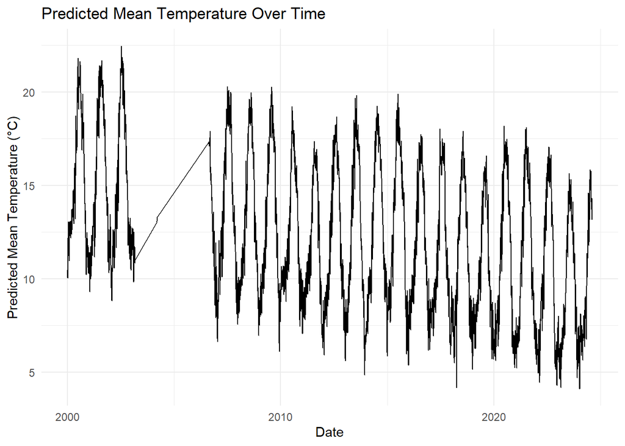

The plot illustrates the predicted minimum temperature of the Feather River HFC over time. The line represents the trend of the predicted minimum temperatures, showing how they vary across different dates. This helps to understand the behavior of the minimum water temperatures in the river.

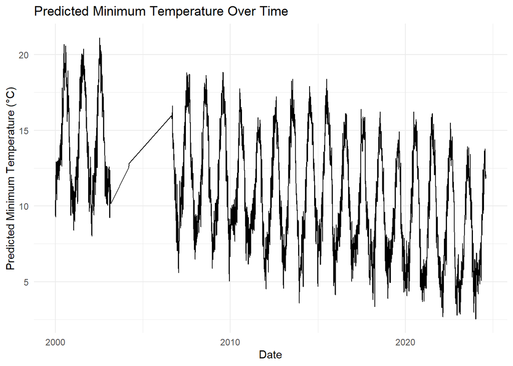

The plot shows the predicted maximum temperature of the Feather River HFC over time. The line indicates the trend of the predicted maximum temperatures, showing how they change with respect to the date. This plot helps to visualize the highest expected water temperatures in the river over the given period.

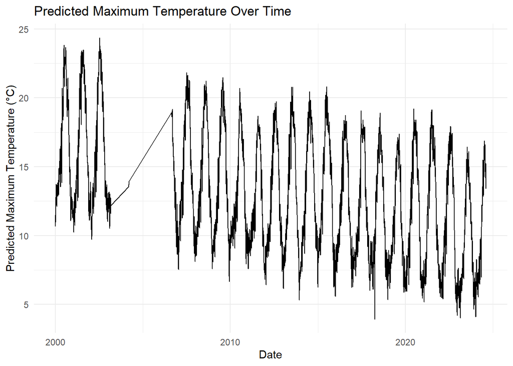

#### Full dataset

- Join with original data (merge combined predictions with the original dataset that includes gage agency and gage number)
- Visualize combined data

The plot shows how the mean, minimum, and maximum temperatures of the Upper Feather River HFC vary over time. Interpolated values are seamlessly integrated where observed data is missing, ensuring a continuous temperature trend. The different colors for each statistic (mean, min, max) help in distinguishing the temperature trends and understanding the temperature fluctuations.

```
## Rows: 26,913
## Columns: 7
## Groups: stream, date, statistic, gage_agency, gage_number, site_group [26,913]
## $ date        <date> 1999-12-31, 1999-12-31, 1999-12-31, 2000-01-01, 2000-01-0…
## $ stream      <chr> "feather river", "feather river", "feather river", "feathe…
## $ site_group  <chr> "upper feather hfc", "upper feather hfc", "upper feather h…
## $ gage_agency <chr> "interpolated", "interpolated", "interpolated", "interpola…
## $ gage_number <chr> "interpolated", "interpolated", "interpolated", "interpola…
## $ statistic   <chr> "mean", "max", "min", "mean", "max", "min", "mean", "max",…
## $ value       <dbl> 10.359181, 10.664014, 10.370228, 10.467286, 11.306022, 10.…
```

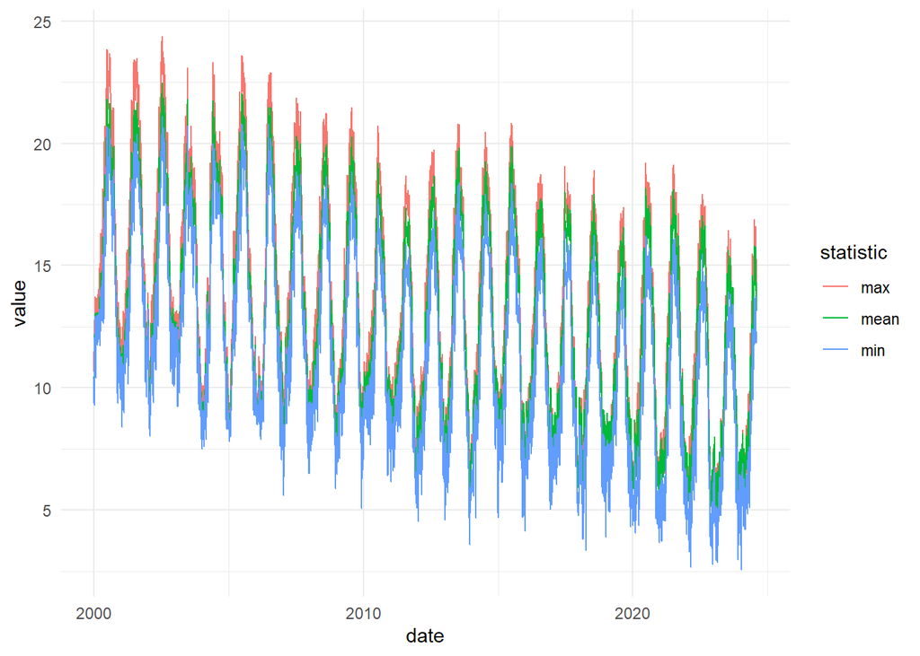

## Yuba River

### Data Prepartion and Approach

1. Pull in gage data from YR7 CDEC gage, however, this only contains data from 2020 onwards. Temperature data collected along with RST data was originally used to fill the gap prior to 2020; however, due to inconsistencies in these data sources the resulting predicted mean values were lower than the min values as the RST data only has mean data.
2. Prepare datasets for regression analysis
- Dataset with no missing data to train (Butte Creek)
- Dataset with missing data to predict (Yuba River)
3. Combine datasets with no missing data, and missing data
4. Identify gaps to predict
5. Use data where there are no missing data for either dataset for regression modeling

#### Visually check the relationship between Butte Creek and Yuba River water temperature

There is a linear correlation between mean water temperature on Butte Creek and Yuba River. The plots bellow suggest a strong linear relationship between the mean, max and min water temperatures of Butte Creek and Yuba River. The positive slope of the linear trend line implies that higher water temperatures in Butte Creek are associated with higher water temperatures in Yuba River. These visual representations support the results of the linear regression analysis, which identified a statistically significant relationship between the mean, max and min water temperatures of these two locations.

*Plot of mean temp for Yuba River and Butte Creek*

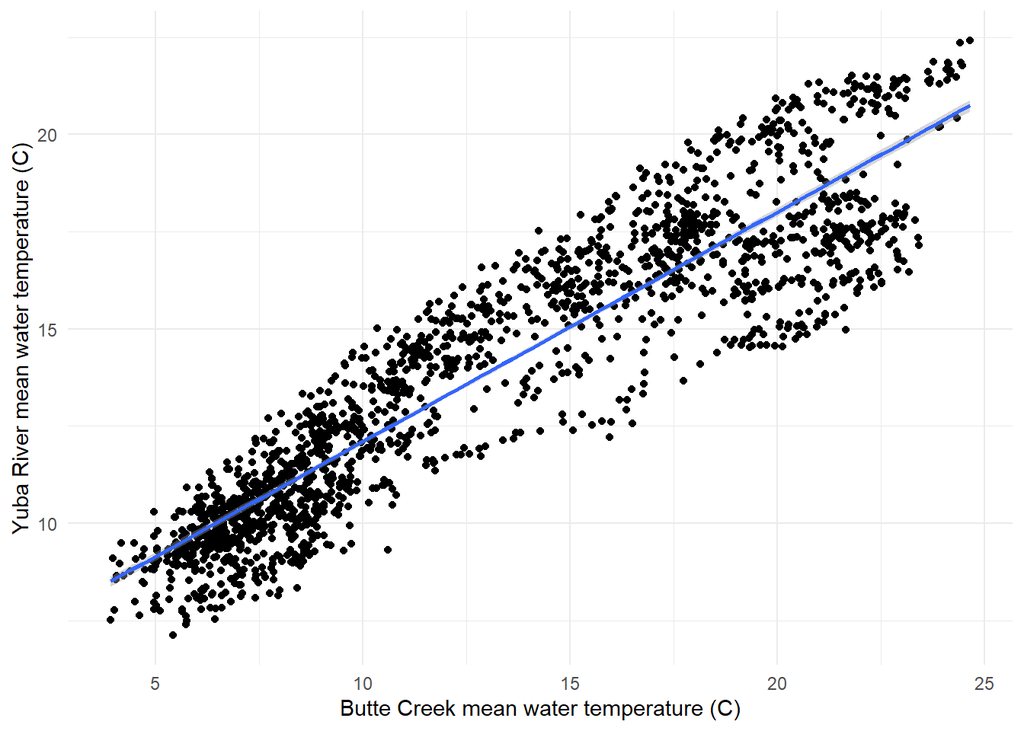

*Plot of min temp for Yuba River and Butte Creek*

Similar to mean temperature, there is a linear correlation for min temperature.

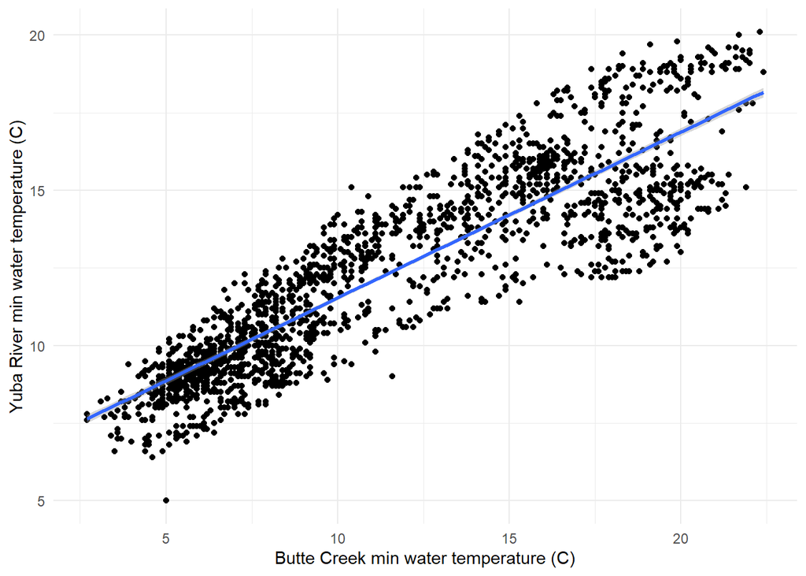

*Plot of max temp for Yuba River and Butte Creek*

Similar to mean and min, there is a linear correlation for max temperature.

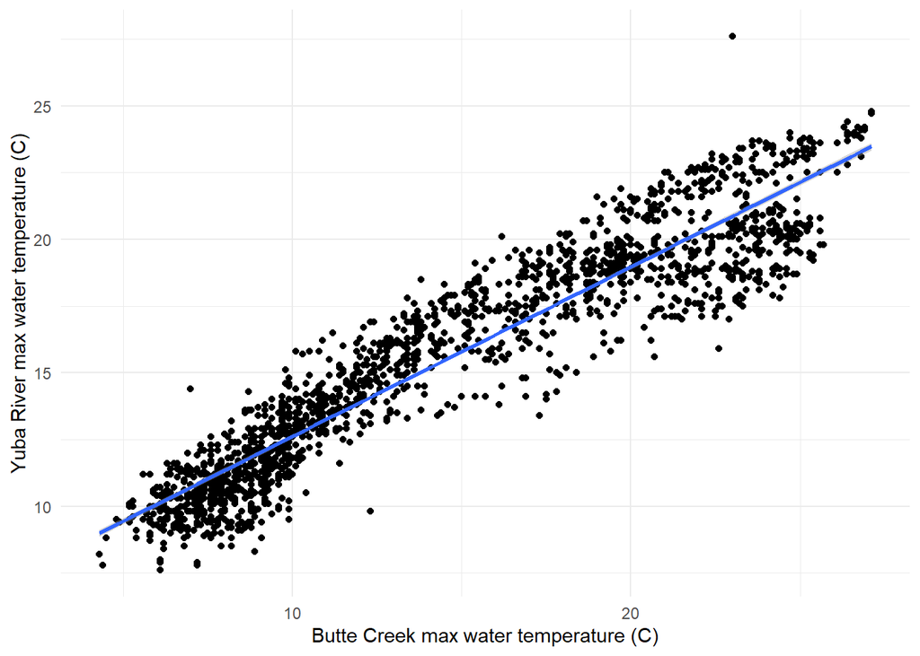

#### Building Mean Regression

- Splitting data
- Building the Model
- Model Summary
- Making predictions
- Evaluating predictions

```
##
## Call:
## lm(formula = temp ~ date + butte_temp, data = train)
##
## Residuals:
##     Min      1Q  Median      3Q     Max
## -3.9346 -0.9217 -0.0004  0.9665  3.1478
##
## Coefficients:
##               Estimate Std. Error t value Pr(>|t|)
## (Intercept)  2.197e+01  1.307e+00   16.81   <2e-16 ***
## date        -8.291e-04  6.863e-05  -12.08   <2e-16 ***
## butte_temp   5.914e-01  6.330e-03   93.43   <2e-16 ***
## ---
## Signif. codes:  0 '***' 0.001 '**' 0.01 '*' 0.05 '.' 0.1 ' ' 1
##
## Residual standard error: 1.355 on 1433 degrees of freedom
## Multiple R-squared:  0.8603, Adjusted R-squared:  0.8601
## F-statistic:  4413 on 2 and 1433 DF,  p-value: < 2.2e-16
```

```
## [1] 0.07707369
```

#### Building Min Regression

- Splitting data
- Building the Model
- Model Summary
- Making predictions
- Evaluating predictions

```
##
## Call:
## lm(formula = temp ~ date + butte_temp, data = train)
##
## Residuals:
##     Min      1Q  Median      3Q     Max
## -4.5194 -0.9266 -0.0128  0.9530  3.2673
##
## Coefficients:
##               Estimate Std. Error t value Pr(>|t|)
## (Intercept)  2.254e+01  1.329e+00   16.96   <2e-16 ***
## date        -8.593e-04  6.976e-05  -12.32   <2e-16 ***
## butte_temp   5.363e-01  7.014e-03   76.47   <2e-16 ***
## ---
## Signif. codes:  0 '***' 0.001 '**' 0.01 '*' 0.05 '.' 0.1 ' ' 1
##
## Residual standard error: 1.376 on 1433 degrees of freedom
## Multiple R-squared:  0.8059, Adjusted R-squared:  0.8056
## F-statistic:  2975 on 2 and 1433 DF,  p-value: < 2.2e-16
```

```
## [1] 0.08855836
```

#### Building Max Regression

- Splitting data
- Building the Model
- Model Summary
- Making predictions
- Evaluating predictions

```
##
## Call:
## lm(formula = temp ~ date + butte_temp, data = train)
##
## Residuals:
##     Min      1Q  Median      3Q     Max
## -4.6346 -0.8797  0.0336  0.9162  6.3446
##
## Coefficients:
##               Estimate Std. Error t value Pr(>|t|)
## (Intercept)  1.862e+01  1.323e+00  14.070   <2e-16 ***
## date        -6.530e-04  6.925e-05  -9.429   <2e-16 ***
## butte_temp   6.396e-01  5.744e-03 111.364   <2e-16 ***
## ---
## Signif. codes:  0 '***' 0.001 '**' 0.01 '*' 0.05 '.' 0.1 ' ' 1
##
## Residual standard error: 1.356 on 1433 degrees of freedom
## Multiple R-squared:  0.8974, Adjusted R-squared:  0.8973
## F-statistic:  6269 on 2 and 1433 DF,  p-value: < 2.2e-16
```

```
## [1] 0.07086515
```

#### Predictions

- Combine Predictions (mean, min, max dataframes into one)
- Reshape data

The plot shows the predicted mean temperature of Yuba River over time. The line represents the trend of the predicted mean temperatures, indicating how they change as the date progresses. This visualization helps to identify any patterns or trends in the mean water temperature over the observed period.

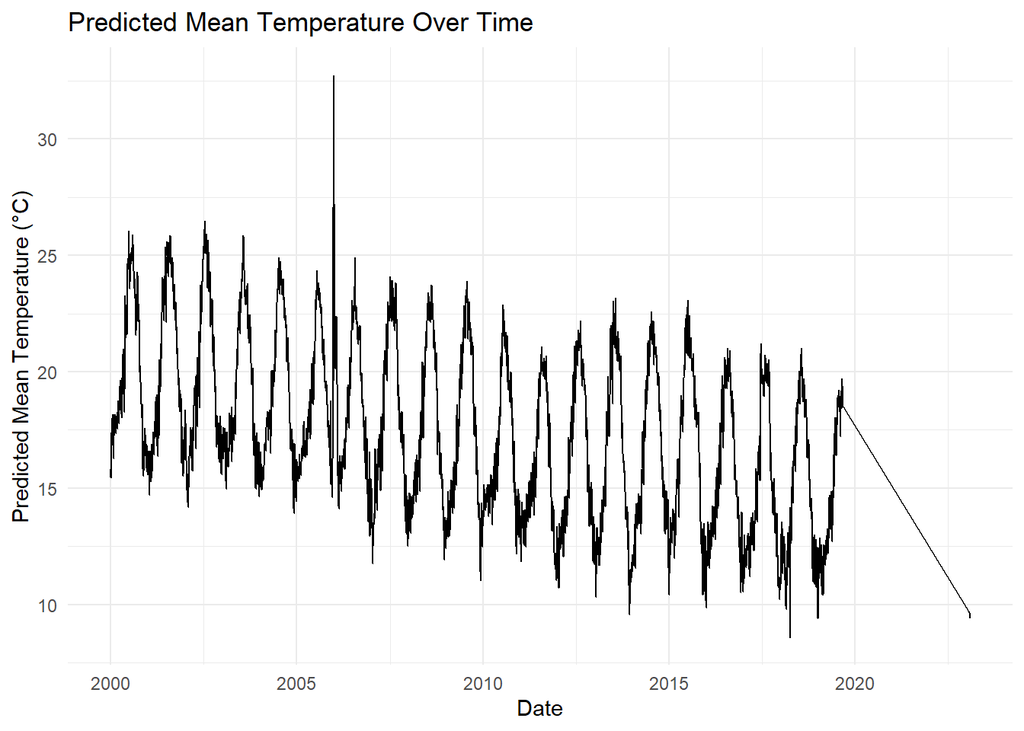

The plot illustrates the predicted minimum temperature of the Yuba River over time. The line represents the trend of the predicted minimum temperatures, showing how they vary across different dates. This helps to understand the behavior of the minimum water temperatures in the river.

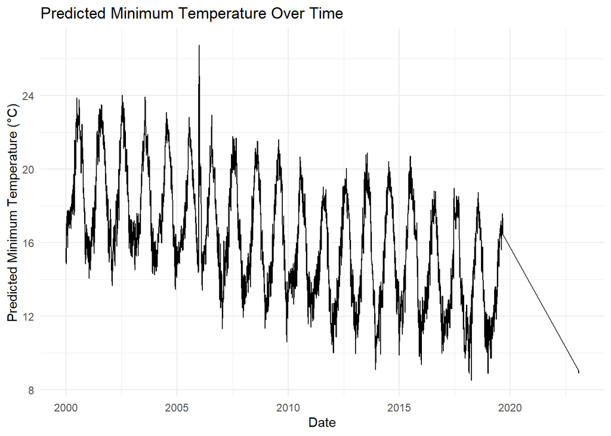

The plot shows the predicted maximum temperature of Yuba River over time. The line indicates the trend of the predicted maximum temperatures, showing how they change with respect to the date. This plot helps to visualize the highest expected water temperatures in the river over the given period.

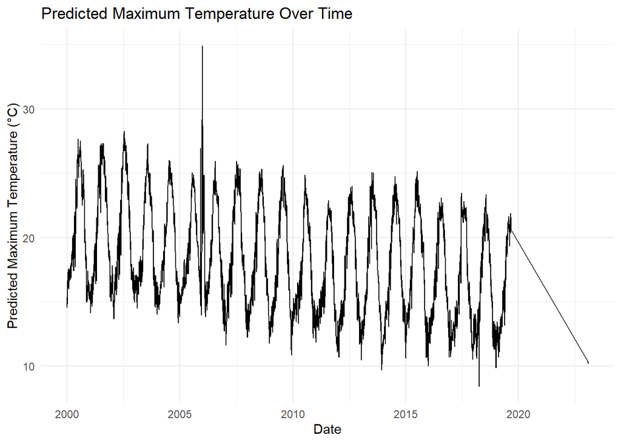

#### Full dataset

- Join with original data (merge combined predictions with the original dataset that includes gage agency and gage number)
- Visualize combined data

The plot shows how the mean, minimum, and maximum temperatures of Yuba River vary over time. Interpolated values are seamlessly integrated where observed data is missing, ensuring a continuous temperature trend. The different colors for each statistic (mean, min, max) help in distinguishing the temperature trends and understanding the temperature fluctuations.

```
## Rows: 26,877
## Columns: 6
## Groups: stream, date, statistic, gage_agency, gage_number [26,877]
## $ date        <date> 1999-12-31, 1999-12-31, 1999-12-31, 2000-01-01, 2000-01-0…
## $ stream      <chr> "yuba river", "yuba river", "yuba river", "yuba river", "y…
## $ gage_agency <chr> "interpolated", "interpolated", "interpolated", "interpola…
## $ gage_number <chr> "interpolated", "interpolated", "interpolated", "interpola…
## $ statistic   <chr> "mean", "max", "min", "mean", "max", "min", "mean", "max",…
## $ value       <dbl> 15.72969, 14.53535, 15.69979, 15.82742, 15.17434, 15.43077…
```

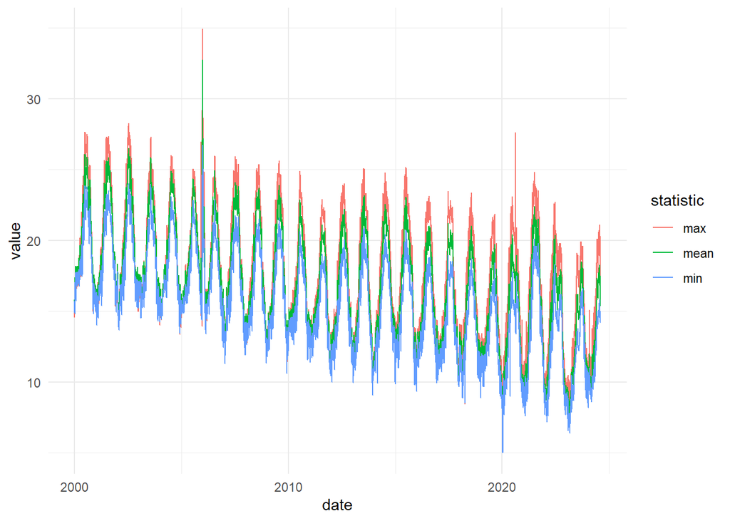